# Importing Some important library

# Lets see Average daly rate are which hotel high wather canceled are high or not

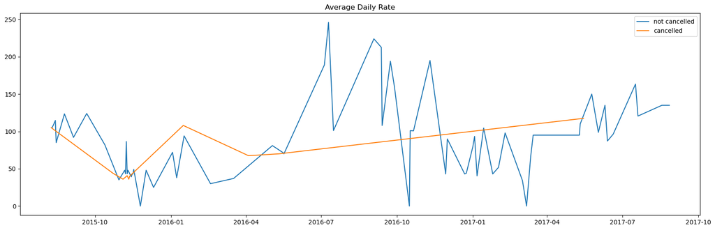

```python
cancelled_df_adr = cancelled_data.groupby('reservation_status_date')[['address']].mean()
cancelled_df_adr.reset_index(inplace=True)
cancelled_df_adr.sort_values('reservation_status_date', inplace=True)

not_cancelled_data = df[df['is_canceled'] == 0]
not_cancelled_df_adr = not_cancelled_data.groupby('reservation_status_date')[['address']].mean()
not_cancelled_df_adr.reset_index(inplace=True)
not_cancelled_df_adr.sort_values('reservation_status_date',inplace=True)

plt.figure(figsize=(20,6))
plt.title('Average Daily Rate')
plt.plot(not_cancelled_df_adr['reservation_status_date'],not_cancelled_df_adr['address'],label='not cancelled')
plt.plot(cancelled_df_adr['reservation_status_date'],cancelled_df_adr['address'], label='cancelled')
plt.legend()
```

```python
df.groupby(['arrival_date_year','arrival_date_month','arrival_date_week_number','arrival_date_day_of_month','address'],as_index=False)['hotel'].sum().sort_values(by='hotel',ascending=True)
```

|  | arrival_date_year | arrival_date_month | arrival_date_week_number | arrival_date_day_of_month | address | hotel |
| --- | --- | --- | --- | --- | --- | --- |
| 0 | 2015 | August | 33 | 9 | 105.00 | City Hotel |
| 69 | 2016 | December | 53 | 27 | 93.36 | City Hotel |
| 70 | 2016 | December | 53 | 31 | 80.00 | City Hotel |
| 72 | 2016 | January | 1 | 2 | 72.00 | City Hotel |
| 74 | 2016 | January | 3 | 16 | 94.00 | City Hotel |
| ... | ... | ... | ... | ... | ... | ... |
| 35 | 2015 | November | 46 | 8 | 36.00 | Resort HotelResort HotelResort HotelResort Hot... |
| 16 | 2015 | November | 45 | 3 | 48.00 | Resort HotelResort HotelResort HotelResort Hot... |
| 48 | 2015 | November | 46 | 12 | 40.00 | Resort HotelResort HotelResort HotelResort Hot... |
| 15 | 2015 | November | 45 | 3 | 40.00 | Resort HotelResort HotelResort HotelResort Hot... |
| 28 | 2015 | November | 45 | 7 | 36.00 | Resort HotelResort HotelResort HotelResort Hot... |

119 rows × 6 columns

# Observation

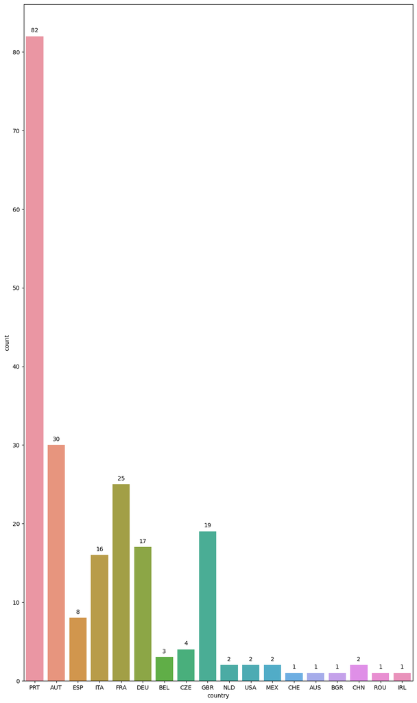

```python
plt.figure(figsize=(12, 21))
tl = sns.countplot(x='country', data=df)
for p in tl.patches:
    tl.annotate(format(p.get_height(), '.0f'),
                   (p.get_x() + p.get_width() / 2., p.get_height()),
                   ha = 'center', va = 'center',
                   xytext = (0, 10),
                   textcoords = 'offset points')
plt.show()
```

```python
df.groupby(['stays_in_week_nights','adults', 'children','meal'],as_index=False)['lead_time'].sum().sort_values(by='lead_time',ascending=True).head()
```

|  | stays_in_week_nights | adults | children | meal | lead_time |
| --- | --- | --- | --- | --- | --- |
| 14 | 3 | 2 | 0.0 | SC | 0 |
| 2 | 0 | 2 | 1.0 | BB | 1 |
| 8 | 1 | 3 | 0.0 | BB | 1 |
| 6 | 1 | 2 | 0.0 | SC | 1 |
| 7 | 1 | 2 | 2.0 | BB | 2 |

# Observation

1.Guests mostly stayed for a small number of week nights, with a significant portion opting for 1 night stays. 2.The dataset reflects a mix of group compositions in terms of adults and children, indicating bookings with varying family sizes. 'BB' meal type (Bed & Breakfast) was commonly selected by guests, potentially indicating a preference for this meal plan. Lead times for bookings varied, showcasing a range of planning behaviors among guests.

```python
df.groupby(['stays_in_weekend_nights','adults', 'children','meal'],as_index=False)['lead_time'].sum().sort_values(by='lead_time',ascending=True).head()
```

|  | stays_in_weekend_nights | adults | children | meal | lead_time |
| --- | --- | --- | --- | --- | --- |
| 8 | 1 | 2 | 0.0 | SC | 0 |
| 2 | 0 | 2 | 0.0 | SC | 1 |
| 5 | 0 | 3 | 0.0 | BB | 1 |
| 9 | 1 | 2 | 1.0 | BB | 1 |
| 3 | 0 | 2 | 1.0 | BB | 5 |

# Observation

```python
shj1 = df.market_segment.value_counts().values
shj2 = df.market_segment.value_counts().index
```

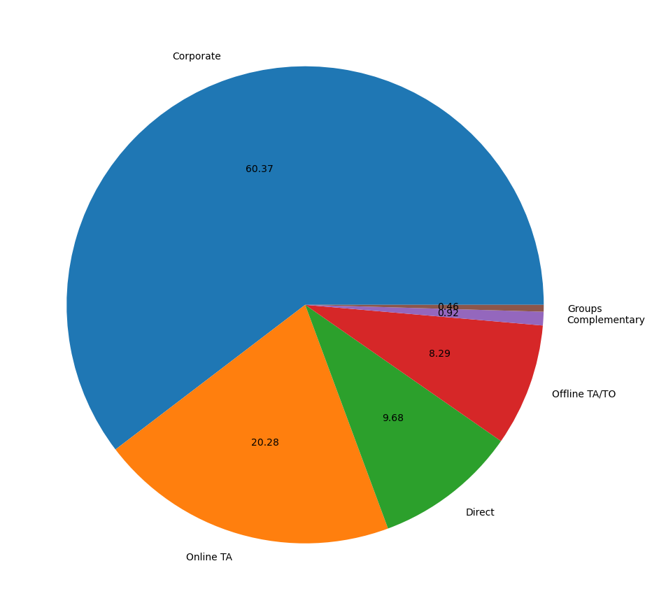

```python
import matplotlib
matplotlib.rcParams['figure.figsize']=(11,19)
plt.pie(x=shj1,labels=shj2,autopct="%1.2f")
plt.show()
```

```python
df.groupby(['is_repeated_guest','hotel']).size().reset_index()
```

|  | is_repeated_guest | hotel | 0 |
| --- | --- | --- | --- |
| 0 | 0 | City Hotel | 42 |
| 1 | 0 | Resort Hotel | 160 |
| 2 | 1 | City Hotel | 5 |
| 3 | 1 | Resort Hotel | 10 |

# Observation

1. The majority of guests in this dataset are not repeated guests, as indicated by the larger count (42 for City Hotel and 160 for Resort Hotel) compared to the counts of repeated guests (5 for City Hotel and 10 for Resort Hotel).
2. There seems to be a higher frequency of bookings in the Resort Hotel compared to the City Hotel, regardless of whether the guest is repeated or not. This suggests that the Resort Hotel may be more popular or have higher demand compared to the City Hotel.

```python
hotel_evol = df.groupby(['country','name','previous_cancellations','previous_bookings_not_canceled','hotel']).size().reset_index().rename(columns={0:'No of counts'})
```

```python
hotel_evol
```

|  | country | name | previous_cancellations | previous_bookings_not_canceled | hotel | No of counts |
| --- | --- | --- | --- | --- | --- | --- |
| 0 | AUS | Xavier Torres | 0 | 0.0 | Resort Hotel | 1 |
| 1 | AUT | Alex Stevenson | 0 | 0.0 | Resort Hotel | 1 |
| 2 | AUT | Amy Hines | 0 | 0.0 | Resort Hotel | 1 |
| 3 | AUT | Angela Matthews | 0 | 0.0 | Resort Hotel | 1 |
| 4 | AUT | Anna Thompson | 0 | 0.0 | Resort Hotel | 1 |
| ... | ... | ... | ... | ... | ... | ... |
| 212 | PRT | Whitney White | 0 | 0.0 | Resort Hotel | 1 |
| 213 | PRT | William Miller | 0 | 0.0 | Resort Hotel | 1 |
| 214 | ROU | Matthew Torres | 0 | 0.0 | City Hotel | 1 |
| 215 | USA | George Wilson | 0 | 0.0 | Resort Hotel | 1 |
| 216 | USA | William Randolph | 0 | 0.0 | Resort Hotel | 1 |

217 rows × 6 columns

# Observation

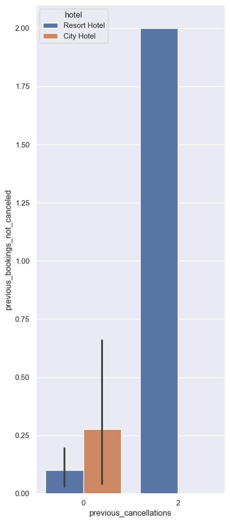

```python
sns.set(rc={'figure.figsize':(5,13)})
sns.barplot(x="previous_cancellations",y="previous_bookings_not_canceled",hue='hotel',data=hotel_evol)
```

```python
#Now we try to find out which country are people maximum room is assigned and reserved in the hotal
df[['country','assigned_room_type','reserved_room_type','hotel']].groupby(['country','assigned_room_type','reserved_room_type','hotel']).size().reset_index()
```

|  | country | assigned_room_type | reserved_room_type | hotel | 0 |
| --- | --- | --- | --- | --- | --- |
| 0 | AUS | E | E | Resort Hotel | 1 |
| 1 | AUT | A | A | Resort Hotel | 14 |
| 2 | AUT | D | A | Resort Hotel | 1 |
| 3 | AUT | E | E | Resort Hotel | 10 |
| 4 | AUT | F | E | Resort Hotel | 2 |
| ... | ... | ... | ... | ... | ... |
| 60 | PRT | G | E | Resort Hotel | 1 |
| 61 | PRT | H | H | Resort Hotel | 2 |
| 62 | PRT | I | E | Resort Hotel | 1 |
| 63 | ROU | A | A | City Hotel | 1 |
| 64 | USA | A | A | Resort Hotel | 2 |

65 rows × 5 columns

# Observation

1. Each row represents a booking from a specific country, showing the assigned room type, reserved room type, and hotel type.
2. We can observe the distribution of assigned and reserved room types within each country. This could provide insights into the preferences of guests from different countries regarding room types.

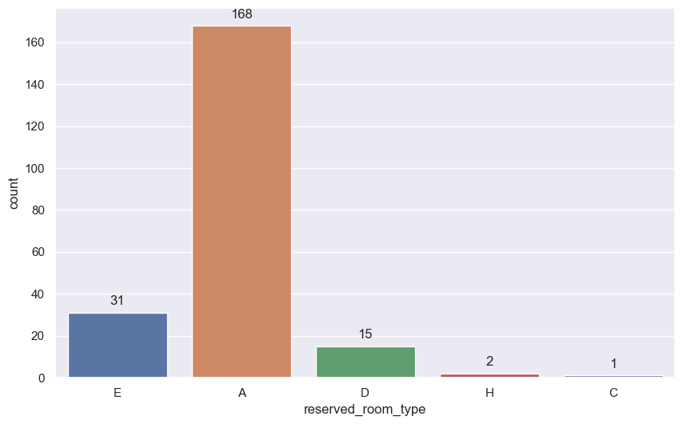

```python
plt.figure(figsize=(10, 6))
kl = sns.countplot(x='reserved_room_type', data=df)

# Iterate through the bars and add labels
for p in kl.patches:
    kl.annotate(format(p.get_height(), '.0f'),
                   (p.get_x() + p.get_width() / 2., p.get_height()),
                   ha = 'center', va = 'center',
                   xytext = (0, 10),
                   textcoords = 'offset points')

plt.show()
```

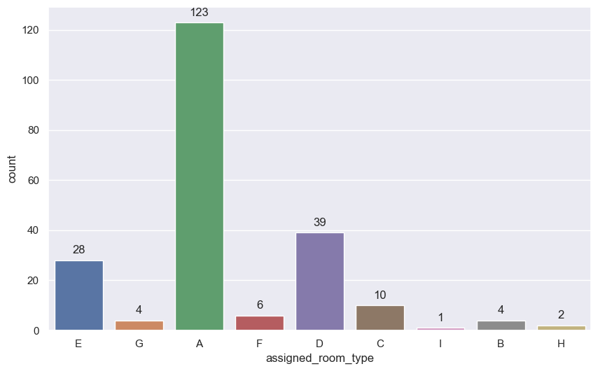

```python
plt.figure(figsize=(10, 6))
kl = sns.countplot(x='assigned_room_type', data=df)

# Iterate through the bars and add labels
for p in kl.patches:
    kl.annotate(format(p.get_height(), '.0f'),
                   (p.get_x() + p.get_width() / 2., p.get_height()),
                   ha = 'center', va = 'center',
                   xytext = (0, 10),
                   textcoords = 'offset points')

plt.show()
```

```python
#we are also try to find on our datasets in which country name are booking_changes & also type of customer,month,phone-number,credit_card on the
#bases of hotel
df.groupby(['country','name','booking_changes','customer_type','month','phone-number', 'credit_card'],as_index=False)['hotel'].sum().sort_values(by='hotel',ascending=True)
```

|  | country | name | booking_changes | customer_type | month | phone-number | credit_card | hotel |
| --- | --- | --- | --- | --- | --- | --- | --- | --- |
| 120 | ITA | Jordan Olson | 1 | Transient | 6 | 860-873-3107 | ************9138 | City Hotel |
| 142 | PRT | Charles Gonzalez | 0 | Transient | 1 | 709-510-6007 | ************2523 | City Hotel |
| 36 | CHN | Daniel Thompson | 0 | Transient-Party | 9 | 340-243-3245 | ************9241 | City Hotel |
| 76 | FRA | Kelsey Anthony | 0 | Transient | 8 | 386-847-8592 | ************9410 | City Hotel |
| 145 | PRT | Denise Curtis | 0 | Transient | 8 | 270-341-8869 | ************7728 | City Hotel |
| ... | ... | ... | ... | ... | ... | ... | ... | ... |
| 86 | FRA | Monica Foster | 1 | Transient-Party | 11 | 300-514-3767 | ************3862 | Resort Hotel |
| 87 | FRA | Nicole Dickerson | 2 | Transient-Party | 11 | 961-392-9860 | ************4187 | Resort Hotel |
| 88 | FRA | Patrick Brown | 1 | Transient-Party | 11 | 387-158-4553 | ************4045 | Resort Hotel |
| 77 | FRA | Kenneth Lee | 3 | Transient-Party | 11 | 696-265-5934 | ************5712 | Resort Hotel |
| 216 | USA | William Randolph | 0 | Transient-Party | 11 | 724-075-0139 | ************5246 | Resort Hotel |

217 rows × 8 columns

# Observation

1. The dataset includes bookings from various countries, such as Italy (ITA), Portugal (PRT), China (CHN), France (FRA), and the United States (USA), among others. This indicates a diverse clientele or geographic spread of hotel guests.
2. Each booking includes details about the customer, such as their name, customer type (Transient, Transient-Party), and contact information (phone number). This information can be valuable for customer relationship management and communication purposes.
3. The "booking_changes" column indicates the number of changes made to the booking before arrival. This could reflect the flexibility or adaptability of guests' travel plans and may impact hotel operations and room management.

```python
df[['country','name','reservation_status','reservation_status_date','days_in_waiting_list','hotel']].groupby(['country','name','reservation_status','reservation_status_date','days_in_waiting_list','hotel']).size().reset_index()
```

|  | country | name | reservation_status | reservation_status_date | days_in_waiting_list | hotel | 0 |
| --- | --- | --- | --- | --- | --- | --- | --- |
| 0 | AUS | Xavier Torres | Check-Out | 2015-11-17 | 0 | Resort Hotel | 1 |
| 1 | AUT | Alex Stevenson | Check-Out | 2015-11-15 | 0 | Resort Hotel | 1 |
| 2 | AUT | Amy Hines | Check-Out | 2015-11-07 | 0 | Resort Hotel | 1 |
| 3 | AUT | Angela Matthews | Check-Out | 2015-11-15 | 0 | Resort Hotel | 1 |
| 4 | AUT | Anna Thompson | Check-Out | 2015-11-15 | 0 | Resort Hotel | 1 |
| ... | ... | ... | ... | ... | ... | ... | ... |
| 212 | PRT | Whitney White | Check-Out | 2015-11-15 | 0 | Resort Hotel | 1 |
| 213 | PRT | William Miller | Check-Out | 2017-03-07 | 0 | Resort Hotel | 1 |
| 214 | ROU | Matthew Torres | Check-Out | 2017-01-03 | 0 | City Hotel | 1 |
| 215 | USA | George Wilson | Check-Out | 2015-11-15 | 0 | Resort Hotel | 1 |
| 216 | USA | William Randolph | Check-Out | 2015-11-16 | 0 | Resort Hotel | 1 |

217 rows × 7 columns

# Observation

```python
df.groupby(['hotel','stays_in_week_nights','stays_in_weekend_nights','required_car_parking_spaces','customer_type','country','name','address']).size().reset_index().rename(columns={0:'No of counts'})
```

|  | hotel | stays_in_week_nights | stays_in_weekend_nights | required_car_parking_spaces | customer_type | country | name | address | No of counts |
| --- | --- | --- | --- | --- | --- | --- | --- | --- | --- |
| 0 | City Hotel | 0 | 1 | 0 | Transient | PRT | Fred Bush | 124.0 | 1 |
| 1 | City Hotel | 0 | 1 | 0 | Transient | PRT | Jeffery Newman | 105.0 | 1 |
| 2 | City Hotel | 0 | 1 | 0 | Transient | PRT | Paula Todd | 123.5 | 1 |
| 3 | City Hotel | 0 | 1 | 0 | Transient-Party | CHN | Daniel Thompson | 108.0 | 1 |
| 4 | City Hotel | 1 | 0 | 0 | Transient | DEU | Jenna Smith | 80.0 | 1 |
| ... | ... | ... | ... | ... | ... | ... | ... | ... | ... |
| 212 | Resort Hotel | 15 | 7 | 0 | Transient-Party | AUT | David Martinez | 52.2 | 1 |
| 213 | Resort Hotel | 15 | 7 | 0 | Transient-Party | AUT | Lynn Gaines | 52.2 | 1 |
| 214 | Resort Hotel | 15 | 7 | 1 | Transient-Party | AUT | Tony James | 58.2 | 1 |
| 215 | Resort Hotel | 15 | 7 | 1 | Transient-Party | PRT | Elizabeth Duran | 52.2 | 1 |
| 216 | Resort Hotel | 21 | 9 | 0 | Transient-Party | PRT | Hannah Flores | 0.0 | 1 |

217 rows × 9 columns

# Observation

1. Hotel Types: The dataset includes bookings for both City Hotel and Resort Hotel. This indicates that the dataset covers a variety of hotel types, catering to different preferences and needs of guests.
2. Length of Stay: The columns "stays_in_week_nights" and "stays_in_weekend_nights" provide information about the duration of stays during weekdays and weekends, respectively. This can help understand the booking patterns of guests and the popularity of stays during different times of the week.
3. Parking space requirements are mostly zero.
4. Diverse customer types and origins.
5. Each booking appears unique.
6. Some guests stay for extended periods.

```python
df.groupby(['total_of_special_requests'],as_index=False)['hotel'].sum().sort_values(by='hotel',ascending=False)
```

|  | total_of_special_requests | hotel |
| --- | --- | --- |
| 0 | 0 | Resort HotelResort HotelResort HotelResort Hot... |
| 1 | 1 | Resort HotelResort HotelResort HotelResort Hot... |
| 2 | 2 | Resort HotelResort HotelCity HotelCity HotelCi... |
| 3 | 3 | Resort HotelCity Hotel |

# Conclusion

To gain more insights and draw meaningful conclusions from this data, it's crucial to ensure proper aggregation and formatting of the 'hotel' column and possibly further analyze the distribution of hotel types within different levels of special requests.